# RLS Modelling for Amanda

#### Model 5: Fishing model on the snail counts with protection and openness (glm)

For this model we are seeing that protection status has a non-significant positive effect on the log snail counts

```
## Levene's Test for Homogeneity of Variance (center = median)
##       Df F value Pr(>F)
## group  1  0.0461 0.8314
##       33
```

```r
snail_fishing_mod_linear <- glmmTMB(log(Turban_Snails +1) ~ norm_openness_scale +
                                      protect_status,
                                    data = env_mod_data,
                                    family = gaussian(link = "identity"))
```

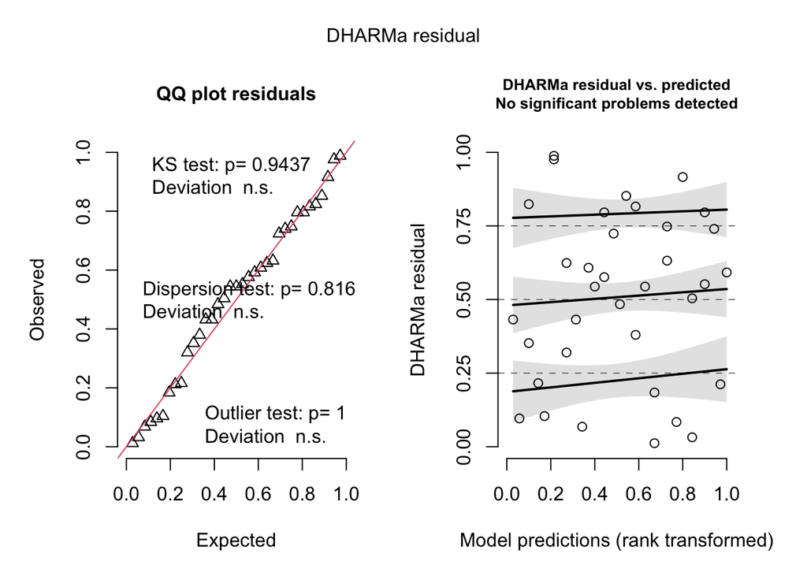

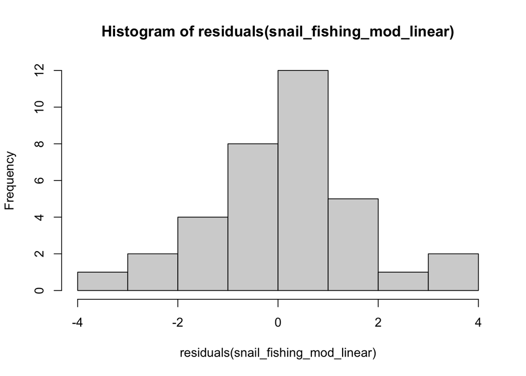

```
##
##  Shapiro-Wilk normality test
##
## data:  residuals(snail_fishing_mod_linear)
## W = 0.9813, p-value = 0.8008
```

```
##  Family: gaussian  ( identity )
## Formula:          log(Turban_Snails + 1) ~ norm_openness_scale + protect_status
## Data: env_mod_data
##
##      AIC      BIC   logLik deviance df.resid
##    134.7    140.9    -63.3    126.7       31
##
##
## Dispersion estimate for gaussian family (sigma^2): 2.18
##
## Conditional model:
##                         Estimate Std. Error z value Pr(>|z|)
## (Intercept)               3.5366     0.3015  11.728  < 2e-16 ***
## norm_openness_scale      -1.0108     0.2709  -3.731 0.000191 ***
## protect_statusProtected   0.4436     0.5911   0.750 0.453001
## ---
## Signif. codes:  0 '***' 0.001 '**' 0.01 '*' 0.05 '.' 0.1 ' ' 1
```

```
## Model has log-transformed response. Back-transforming predictions to
##   original response scale. Standard errors are still on the log-scale.
```

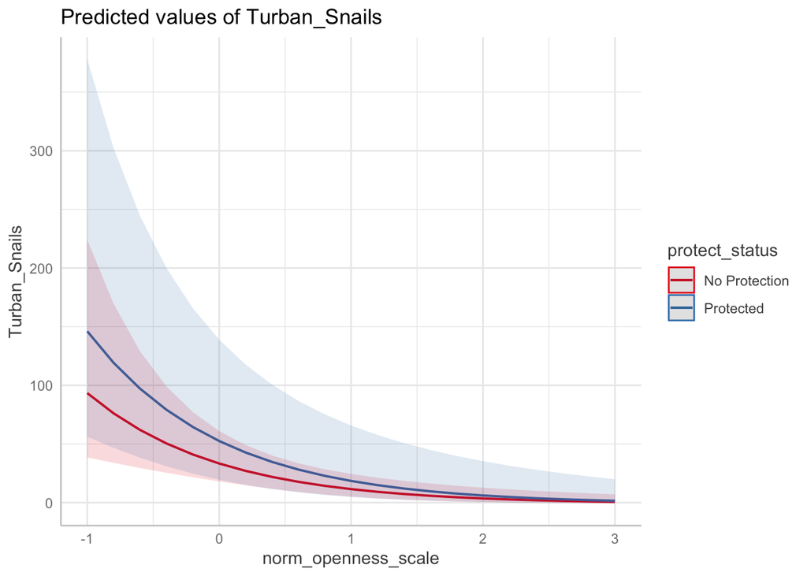

```
## Model has log-transformed response. Back-transforming predictions to
##   original response scale. Standard errors are still on the log-scale.
```

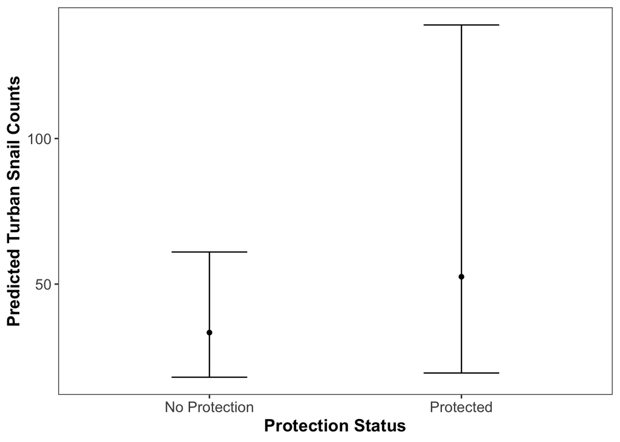

##### Testing the residuals for autocorrelation

```
##
##  Moran I test under randomisation
##
## data:  residuals_snail_fishing_mod_linear
## weights: lw
## n reduced by no-neighbour observations
##
## Moran I statistic standard deviate = 1.2368, p-value = 0.2162
## alternative hypothesis: two.sided
## sample estimates:
## Moran I statistic       Expectation          Variance
##        0.33851812       -0.05882353        0.10321884
```

```
##
##  Moran I test under randomisation
##
## data:  residuals_snail_fishing_mod_linear
## weights: lw_inverse
##
## Moran I statistic standard deviate = 2.2831, p-value = 0.02243
## alternative hypothesis: two.sided
## sample estimates:
## Moran I statistic       Expectation          Variance
##        0.35848733       -0.02941176        0.02886729
```

No autocorrelation with neighbours but it is significant with inverse distance.

#### Model 6: Fishing model on the snail counts with just protection (glm)

```r
snail_fishing_mod_linear_no_op <- glmmTMB(log(Turban_Snails +1) ~
                                      protect_status,
                                    data = env_mod_data,
                                    family = gaussian(link = "identity"))
```

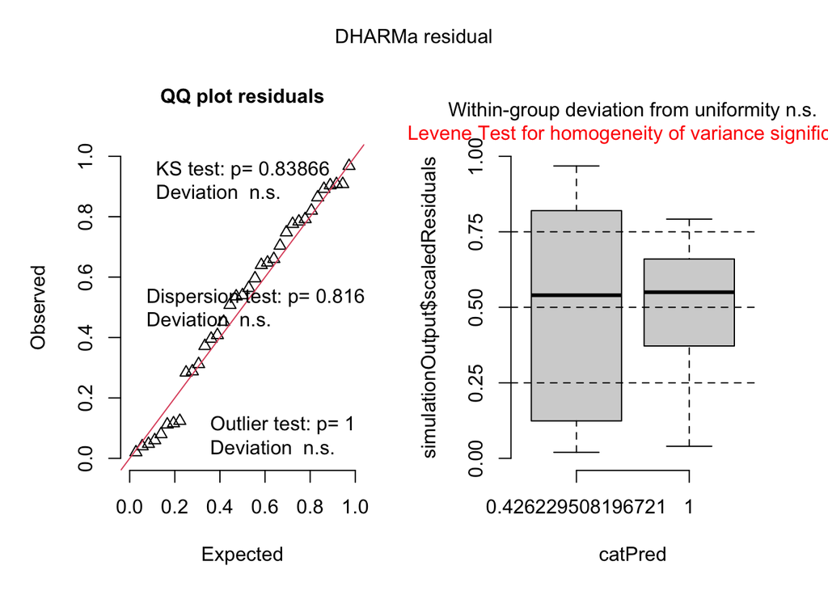

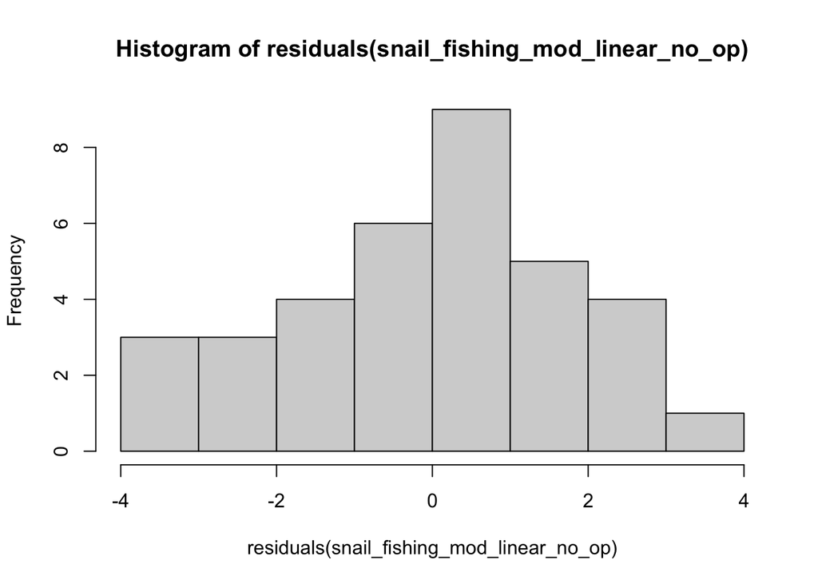

```
##
##  Shapiro-Wilk normality test
##
## data:  residuals(snail_fishing_mod_linear_no_op)
## W = 0.96004, p-value = 0.2293
```

```
##  Family: gaussian  ( identity )
## Formula:          log(Turban_Snails + 1) ~ protect_status
## Data: env_mod_data
##
##      AIC      BIC   logLik deviance df.resid
##    144.4    149.1    -69.2    138.4       32
##
##
## Dispersion estimate for gaussian family (sigma^2): 3.05
##
## Conditional model:
##                         Estimate Std. Error z value Pr(>|z|)
## (Intercept)               3.3138     0.3494   9.483   <2e-16 ***
## protect_statusProtected   1.2233     0.6537   1.871   0.0613 .
## ---
## Signif. codes:  0 '***' 0.001 '**' 0.01 '*' 0.05 '.' 0.1 ' ' 1
```

```
## Model has log-transformed response. Back-transforming predictions to
##   original response scale. Standard errors are still on the log-scale.
```

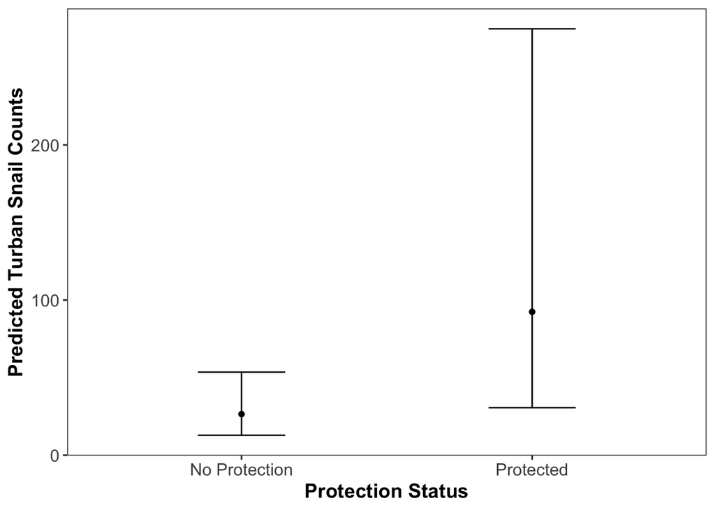

##### Testing the residuals for autocorrelation

```
##
##  Moran I test under randomisation
##
## data:  residuals_snail_fishing_mod_linear_no_op
## weights: lw
## n reduced by no-neighbour observations
##
## Moran I statistic standard deviate = 0.73318, p-value = 0.4634
## alternative hypothesis: two.sided
## sample estimates:
## Moran I statistic       Expectation          Variance
##        0.18307715       -0.05882353        0.10885553
```

```
##
##  Moran I test under randomisation
##
## data:  residuals_snail_fishing_mod_linear_no_op
## weights: lw_inverse
##
## Moran I statistic standard deviate = 1.3682, p-value = 0.1712
## alternative hypothesis: two.sided
## sample estimates:
## Moran I statistic       Expectation          Variance
##        0.20579287       -0.02941176        0.02955093
```

No autocorrelation.

### Red Sea Urchin fishing models

#### Plot of urchin counts between protection status

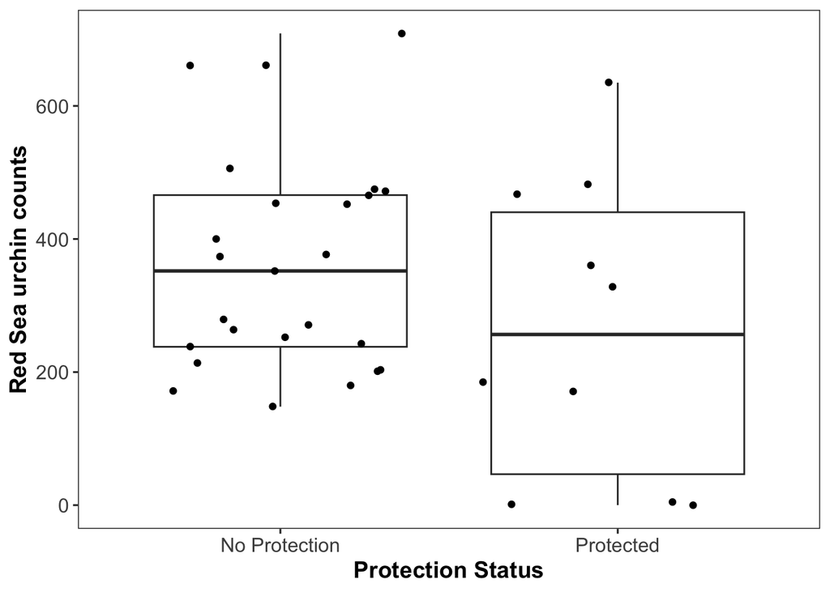

```r
ggplot(env_mod_data, aes(x = protect_status, y = Urchins))+
  geom_boxplot()+
  geom_jitter()+
  labs(x = "Protection Status", y = "Red Sea urchin counts")+
  theme.figure()
```

#### Model 7: Fishing model on the urchin counts (glm)

```
## Levene's Test for Homogeneity of Variance (center = median)
##       Df F value Pr(>F)
## group  1  2.7654 0.1058
##       33
```

Equal variance between protected and non-protected sites so assumption of homogeneity of variance is met.

```r
urchin_fishing_mod_glm <- glmmTMB(Urchins ~ protect_status,
                               family = gaussian(link = "identity"),
                                   data = env_mod_data)
```

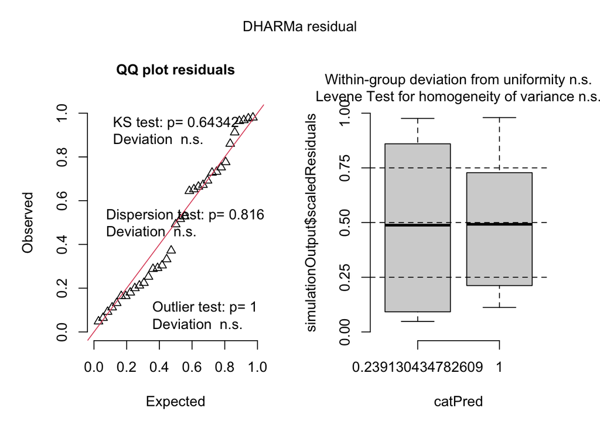

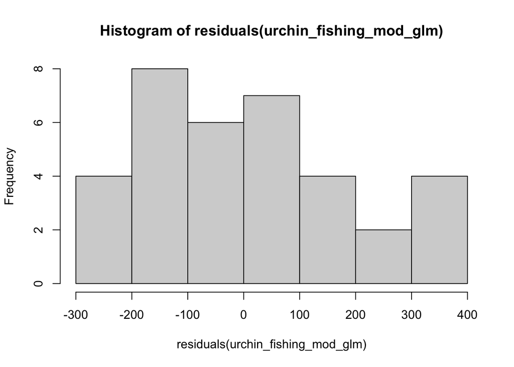

```
##
##  Shapiro-Wilk normality test
##
## data:  residuals(urchin_fishing_mod_glm)
## W = 0.95037, p-value = 0.1164
```

```
##  Family: gaussian  ( identity )
## Formula:          Urchins ~ protect_status
## Data: env_mod_data
##
##      AIC      BIC   logLik deviance df.resid
##    467.4    472.1   -230.7    461.4       32
##
##
## Dispersion estimate for gaussian family (sigma^2): 3.11e+04
##
## Conditional model:
##                         Estimate Std. Error z value Pr(>|z|)
## (Intercept)               360.96      35.28  10.231   <2e-16 ***
## protect_statusProtected   -97.56      66.00  -1.478    0.139
## ---
## Signif. codes:  0 '***' 0.001 '**' 0.01 '*' 0.05 '.' 0.1 ' ' 1
```

Residuals look ok for just using a gaussian distribution. Seeing a non-significant negative effect of protection status on red sea urchins. That is, there are less red sea urchins in protected sites.

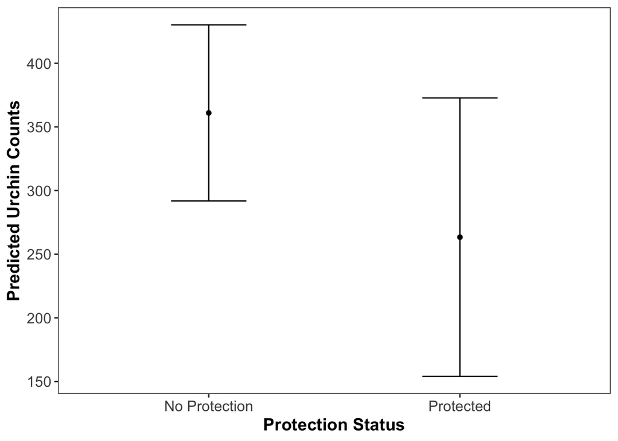

##### Testing the residuals for autocorrelation

```
##
##  Moran I test under randomisation
##
## data:  residuals_urchin_fishing_mod_glm
## weights: lw
## n reduced by no-neighbour observations
##
## Moran I statistic standard deviate = 1.493, p-value = 0.1354
## alternative hypothesis: two.sided
## sample estimates:
## Moran I statistic       Expectation          Variance
##        0.43260455       -0.05882353        0.10833608
```

```
##
##  Moran I test under randomisation
##
## data:  residuals_urchin_fishing_mod_glm
## weights: lw_inverse
##
## Moran I statistic standard deviate = 2.6723, p-value = 0.007533
## alternative hypothesis: two.sided
## sample estimates:
## Moran I statistic       Expectation          Variance
##        0.42947564       -0.02941176        0.02948792
```

Seeing some autocorrelation in the inverse method but not the neighbour method.

## Urchin Snail ratio models

### Model 8: Urchin Snail Ratio fishing model (glm)

```
## Levene's Test for Homogeneity of Variance (center = median)
##       Df F value Pr(>F)
## group  1   2.038 0.1628
##       33
```

Variance is equal between protection status.

```r
urch_sn_ratio_protection_model_glmm <- glmmTMB(urch_sn_ratio ~ protect_status +
                          (1|region1),
                          data = env_mod_data,
                          family = gaussian(link = "identity"))
```

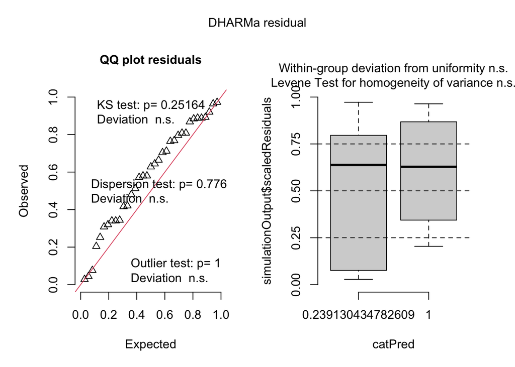

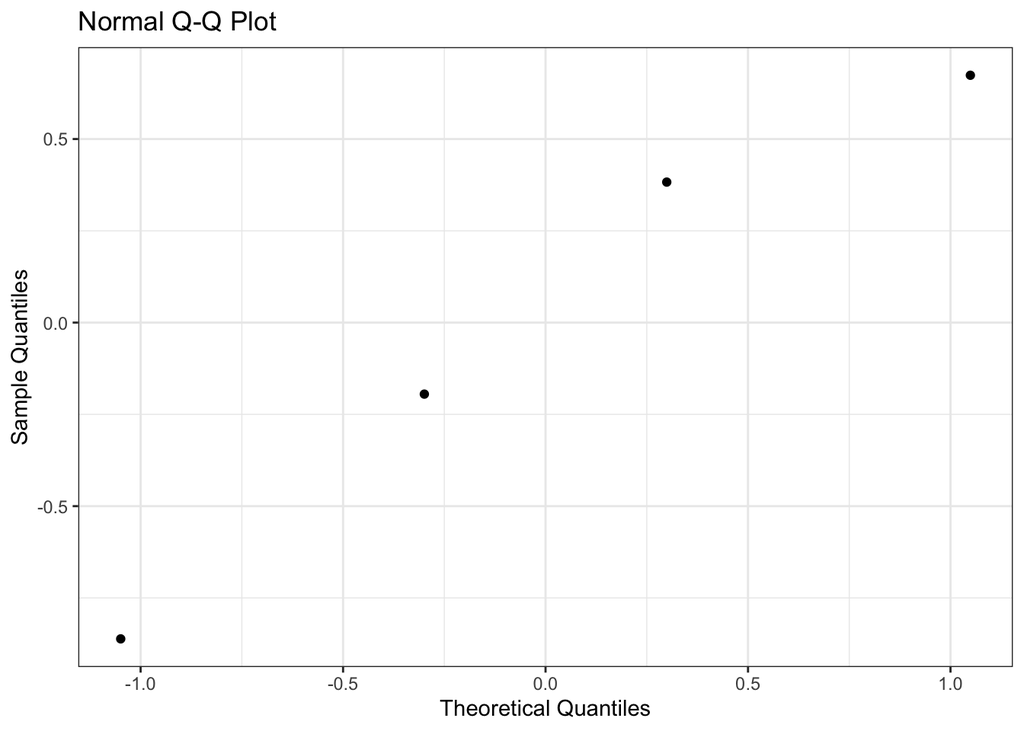

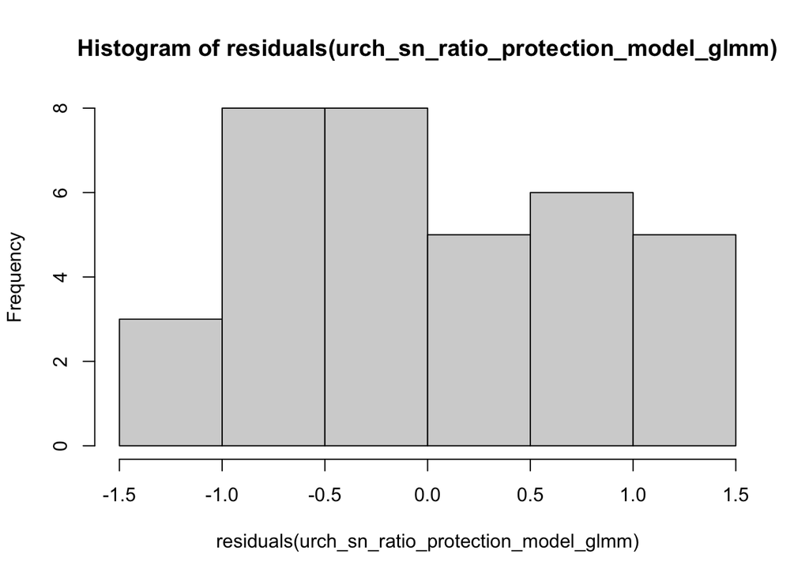

```
##
##  Shapiro-Wilk normality test
##
## data:  residuals(urch_sn_ratio_protection_model_glmm)
## W = 0.94726, p-value = 0.09332
```

```
##  Family: gaussian  ( identity )
## Formula:          urch_sn_ratio ~ protect_status + (1 | region1)
## Data: env_mod_data
##
##      AIC      BIC   logLik deviance df.resid
##    100.9    107.1    -46.4     92.9       31
##
## Random effects:
##
## Conditional model:
##  Groups   Name        Variance Std.Dev.
##  region1  (Intercept) 0.4357   0.6601
##  Residual             0.6844   0.8273
## Number of obs: 35, groups:  region1, 4
##
## Dispersion estimate for gaussian family (sigma^2): 0.684
##
## Conditional model:
##                         Estimate Std. Error z value Pr(>|z|)
## (Intercept)               0.7679     0.4334   1.772   0.0765 .
## protect_statusProtected  -0.8759     0.4346  -2.015   0.0439 *
## ---
## Signif. codes:  0 '***' 0.001 '**' 0.01 '*' 0.05 '.' 0.1 ' ' 1
```

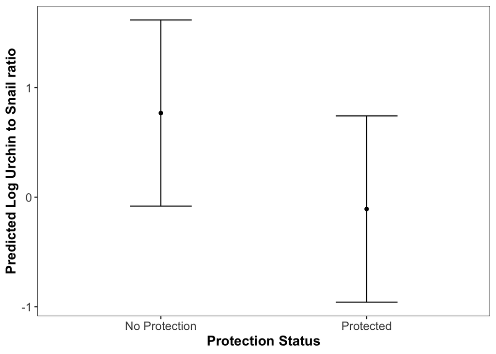

##### Testing the residuals for autocorrelation

```
##
##  Moran I test under randomisation
##
## data:  residuals_urch_sn_ratio_protection_model_glmm
## weights: lw
## n reduced by no-neighbour observations
##
## Moran I statistic standard deviate = 0.90949, p-value = 0.3631
## alternative hypothesis: two.sided
## sample estimates:
## Moran I statistic       Expectation          Variance
##        0.24554077       -0.05882353        0.11199294
```

```
##
##  Moran I test under randomisation
##
## data:  residuals_urch_sn_ratio_protection_model_glmm
## weights: lw_inverse
##
## Moran I statistic standard deviate = 1.4566, p-value = 0.1452
## alternative hypothesis: two.sided
## sample estimates:
## Moran I statistic       Expectation          Variance
##        0.22259510       -0.02941176        0.02993144
```